# Estudio_igraph

Fernando Alvarado

2025-03-07

```
##      years        salary
##  Min.   : 1   Min.   : 25597
##  1st Qu.: 7   1st Qu.: 60072
##  Median :13   Median : 98561
##  Mean   :13   Mean   :117578
##  3rd Qu.:19   3rd Qu.:166981
##  Max.   :25   Max.   :312549
```

Segun los datos en promedio un trabajador tiene 13 años de experiencia ganando en promedio 117,578 unidades.

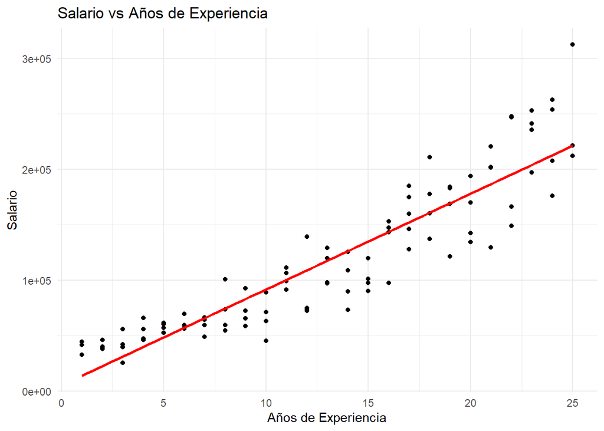

Grafica que representa a nuestros datos junto con nuestro modelo de regresion lineal

### Verificando los supuestos de mi modelo

#### Verificando linealidad

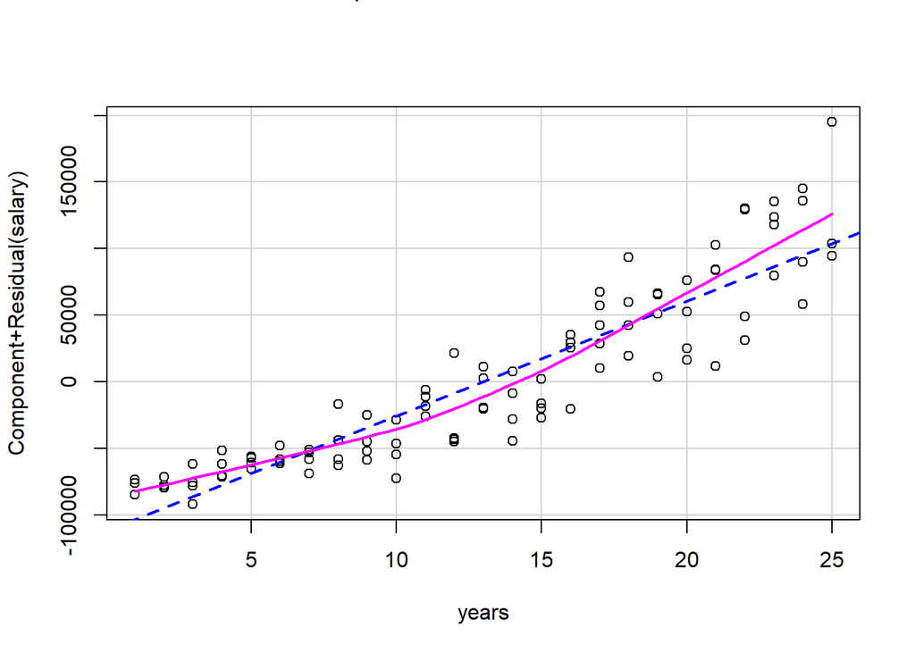

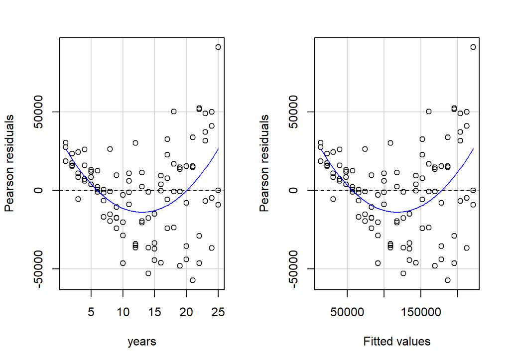

```
##            Test stat Pr(>|Test stat|)
## years         5.1744        1.233e-06 ***
## Tukey test    5.1744        2.286e-07 ***
## ---
## Signif. codes:  0 '***' 0.001 '**' 0.01 '*' 0.05 '.' 0.1 ' ' 1
```

Con estas graficas y la prueba de hipotesis que acabamos de hacer, podemos concluir que no hay evidencia estadistica que no indiue que nuestro modelo de regresion sea lineal, ya que el p-value es de 2.286e-07, por lo que se rechaza H0